# R Notebook

Looking at basic exploratory analysis of the summary stats for response inhibition.

```r
#install.packages("tidystats")
library(stringr)
library(dplyr)
library(ggplot2)
library(rstatix)
data_path <- "../../../files/data/"

load("~/Dropbox (University of Oregon)/UO-SAN Lab/Berkman Lab/Devaluation/analysis_files/data/scored_data_w_demographics.RData")
dropbox_file_dir = "~/Dropbox (University of Oregon)/UO-SAN Lab/Berkman Lab/Devaluation/analysis_files/data/"
scored<-scored_with_demographics
rm(scored_with_demographics)
scored$score <- as.numeric(scored$score)
```

```
NAs introduced by coercion
```

```r
scored$scale_name <- sub("-","_",scored$scale_name)
```

```r
#
scored %>% filter(scale_name %in% c("FCI")) %>% select(scored_scale) %>% unique
```

|  | scored_scale |
| --- | --- |
| 12663 | cancer_preventing |
| 12864 | cancer_promoting |
| 13065 | craved_cancer_preventing |
| 13266 | craved_cancer_promoting |
| 13467 | dairy |
| 13668 | empty_calories |
| 13869 | fried_food |
| 14070 | fruit |
| 14271 | grains |
| 14472 | liked_cancer_preventing |

[output cut: 7 more lines]

```r
NA
```

```r
scored$scale_name %>% unique
```

```
 [1] "MESA"   "FTND"   "BFI"    "BSCS"   "IPAQ"   "NCS"    "PLAN"   "SRHI"   "TESQ_E" "TRSQ"   "VVIQ"
[12] "BIS_11" "cSES"   "EDM"    "FCI"    "FFQ"    "PCS"    "RMQ"    "RS"     "RTFS"   "ACES"   "IMI"
[23] "DEMO"
```

Now get BMI

```r
load("../../../files/data/ppt_list_w_data.RData")

ppt_list_w_data$date_0<-as.Date(ppt_list_w_data$date_0)
ppt_list_w_data$dob<-as.Date(ppt_list_w_data$dob)
ppt_list_w_data$age365<- as.numeric((ppt_list_w_data$date_0-ppt_list_w_data$dob)/365)

#our primary health outcome measure
ppt_health_outcomes <- ppt_list_w_data %>% select(dev_id,bf_1,weight_0,height_0,birthsex,age365,bmi_0,bmi_1) %>% filter(!is.na(bf_1))

ppt_health_outcomes$bmi <- ifelse(!is.na(ppt_health_outcomes$bmi_0),ppt_health_outcomes$bmi_0,ppt_health_outcomes$bmi_1)
rm(ppt_list_w_data)

#remove data of implausible bf_1 values
ppt_health_outcomes$bf_1[ppt_health_outcomes$bf_1<13]<-NA


#get a bf_1 score with sex regressed out
#do we want to regress out height as well???

#plot(ppt_health_outcomes$height_0,ppt_health_outcomes$bf_1)

#hmm that's fairly strong.
#but does it hold after controlling for sex?
#I think it would be good to regress out height as well.
#so we will use a linear model to predict bf_1 from height and sex.
cor.test(ppt_health_outcomes[birthsex==1, height_0],ppt_health_outcomes[birthsex==1,bf_1])
```

```
    Pearson's product-moment correlation

data:  ppt_health_outcomes[birthsex == 1, height_0] and ppt_health_outcomes[birthsex == 1, bf_1]
t = 1.4125, df = 94, p-value = 0.1611
alternative hypothesis: true correlation is not equal to 0
95 percent confidence interval:
 -0.05799594  0.33497047
sample estimates:
      cor
0.1441663
```

```r
cor.test(ppt_health_outcomes[birthsex==2, height_0],ppt_health_outcomes[birthsex==2,bf_1])
```

```
    Pearson's product-moment correlation

data:  ppt_health_outcomes[birthsex == 2, height_0] and ppt_health_outcomes[birthsex == 2, bf_1]
t = 0.29424, df = 42, p-value = 0.77
alternative hypothesis: true correlation is not equal to 0
95 percent confidence interval:
 -0.2549579  0.3376889
sample estimates:
       cor
0.04535554
```

```r
#it does not.

#what about age?
cor.test(ppt_health_outcomes[birthsex==1, age365],ppt_health_outcomes[birthsex==1,bf_1])
```

```
    Pearson's product-moment correlation

data:  ppt_health_outcomes[birthsex == 1, age365] and ppt_health_outcomes[birthsex == 1, bf_1]
t = 2.4228, df = 108, p-value = 0.01706
alternative hypothesis: true correlation is not equal to 0
95 percent confidence interval:
 0.04157285 0.39739415
sample estimates:
      cor
0.2270469
```

```r
cor.test(ppt_health_outcomes[birthsex==2, age365],ppt_health_outcomes[birthsex==2,bf_1])
```

```
    Pearson's product-moment correlation

data:  ppt_health_outcomes[birthsex == 2, age365] and ppt_health_outcomes[birthsex == 2, bf_1]
t = 1.5234, df = 53, p-value = 0.1336
alternative hypothesis: true correlation is not equal to 0
95 percent confidence interval:
 -0.0639499  0.4458903
sample estimates:
      cor
0.2048222
```

```r
#might be a moderate correlation within birth sex levels of age. so it is worth norming for age too
#if we were just controlling for a single variable we could z-score
#but now we're doing age as well.
#which would imply not z-scoring, we should use a linear model.

bf_model <- lm(bf_1~birthsex+age365, ppt_health_outcomes)
summary(bf_model)
```

```
Call:
lm(formula = bf_1 ~ birthsex + age365, data = ppt_health_outcomes)

Residuals:
     Min       1Q   Median       3Q      Max
-14.9475  -4.8883   0.6797   4.5330  14.5750

Coefficients:
            Estimate Std. Error t value Pr(>|t|)
(Intercept) 46.51859    2.37842  19.559  < 2e-16 ***
birthsex    -8.88159    1.09761  -8.092 1.32e-13 ***
age365       0.12653    0.04409   2.870  0.00465 **
---
Signif. codes:  0 ‘***’ 0.001 ‘**’ 0.01 ‘*’ 0.05 ‘.’ 0.1 ‘ ’ 1

Residual standard error: 6.585 on 162 degrees of freedom
  (3 observations deleted due to missingness)
Multiple R-squared:  0.3347,    Adjusted R-squared:  0.3265
F-statistic: 40.75 on 2 and 162 DF,  p-value: 4.62e-15
```

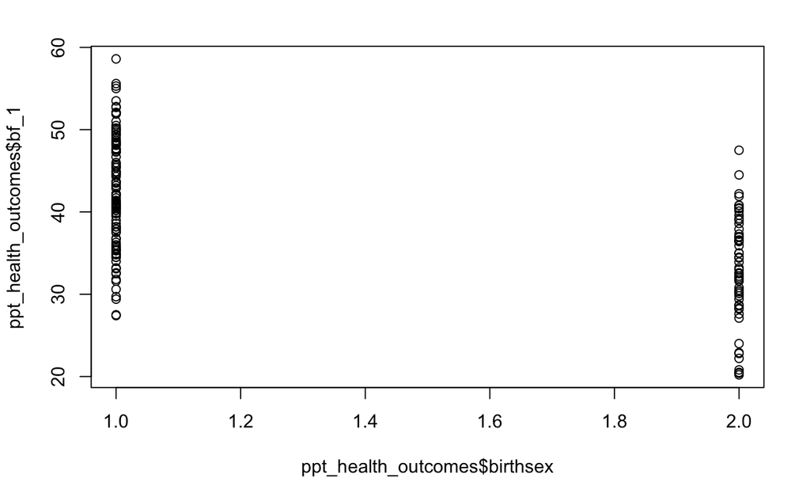

```r
#ppt_health_outcomes$bf_1_controlled <-NULL <- bf_model$residuals
ppt_health_outcomes$bf_1_controlled[as.numeric(rownames(bf_model$model))] <- bf_model$residuals

#simple model just zscoring within sex
#that allows for a more inuitive interpretation than errors from a linear model.
ppt_health_outcomes %<>% group_by(birthsex) %>% mutate(
  bf_1_bsexnormedzs = (bf_1-mean(bf_1,na.rm = TRUE))/sd(bf_1,na.rm = TRUE),

)


#cor.test(ppt_health_outcomes$birthsex,ppt_health_outcomes$bf_1)
plot(ppt_health_outcomes$birthsex,ppt_health_outcomes$bf_1)
```

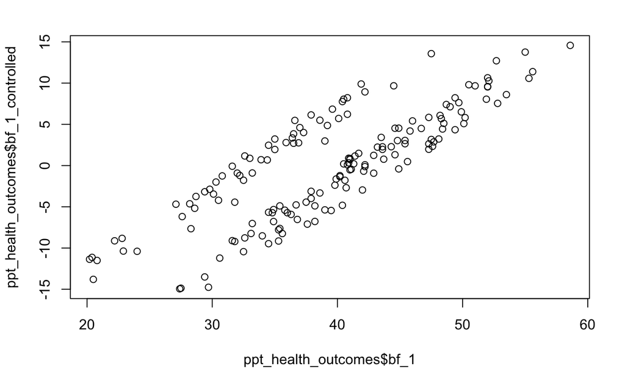

```r
#cor.test(ppt_health_outcomes$birthsex,ppt_health_outcomes$bf_1_bsexnormedzs)
#plot(ppt_health_outcomes$birthsex,ppt_health_outcomes$bf_1_bsexnormedzs)

#plot(ppt_health_outcomes$birthsex,ppt_health_outcomes$bf_1_controlled)

plot(ppt_health_outcomes$bf_1,ppt_health_outcomes$bf_1_controlled)
```

```r
NA
NA
NA
NA
```

```r
min(ppt_health_outcomes$age365)
```

```
[1] 18.59178
```

```r
max(ppt_health_outcomes$age365)
```

```
[1] 60.75616
```

```r
table(ppt_health_outcomes$birthsex)
```

```
  1   2
110  56
```

Now get behavioral measures.

```r
#sst_pes <- readr::read_csv("https://www.dropbox.com/s/vaubgp23y5j0m5g/post_error_slowing.csv?dl=0")
sst_pes <- readr::read_csv(paste0("~/Dropbox (University of Oregon)/UO-SAN Lab/Berkman Lab/Devaluation/analysis_files/data/", "post_error_slowing.csv"))
sst_pes_simple <- readr::read_csv(paste0("~/Dropbox (University of Oregon)/UO-SAN Lab/Berkman Lab/Devaluation/analysis_files/data/", "post_error_slowing_simple_approach.5.7.22.csv"))
#should be wave 1 by default.
sst_data_1 <- readr::read_csv(file=paste0(data_path,"sst_summary_stats_by_run.csv"))
sst_data_2 <- readr::read_csv(file=paste0(data_path,"sst_pre_analyzed_stats.csv"))
sst_data_1_w1 <- sst_data_1%>%filter(runid==1)%>% select(-runid)
sst_data_2_w1 <- sst_data_2 %>% filter(wave==1) %>% select(-wave)
sst_w1 <- merge(sst_data_1_w1,sst_data_2_w1,by.x ="subid",by.y="SubjectLabel",all = TRUE) %>%
  merge(sst_pes[,2:ncol(sst_pes)],by="subid",all=TRUE) %>%
  merge(sst_pes_simple[,2:ncol(sst_pes_simple)],by="subid",all=TRUE)



roc_data <- readr::read_csv(file=paste0(data_path,"roc_summary_stats.csv"))
load(file=paste0(data_path,"wtp_summary_stats_across_runs.Rdata"))




#need to group across run
roc_data_across_runs<- roc_data %>% select(-run) %>% group_by(subjectID,wave) %>% summarise(across(everything(), mean))
roc_data_across_runs_w1 <- roc_data_across_runs %>%filter(wave==1)%>% select(-wave)

wtp_across_runs_wide <- wtp_across_runs %>% select(subject, value_level_mean, health_cond,wave) %>% group_by(subject,wave) %>% spread("health_cond","value_level_mean") %>% ungroup
wtp_across_runs_wide$unhealthy_minus_healthy <- wtp_across_runs_wide$unhealthy - wtp_across_runs_wide$healthy
wtp_across_runs_wide_w1 <- wtp_across_runs_wide%>%filter(wave==1) %>% select(-wave)
colnames(wtp_across_runs_wide_w1) <- paste0("WTP_",colnames(wtp_across_runs_wide_w1))



#sst_data$wave <- 1
colnames(sst_w1) <- paste0("SST_",colnames(sst_w1))
roc_data_across_runs_w1 <- rename(roc_data_across_runs_w1,c(subid=subjectID))
colnames(roc_data_across_runs_w1) <- paste0("ROC_",colnames(roc_data_across_runs_w1))
#roc_data_across_runs$runid <- as.double(stringr::str_match(roc_data_across_runs$run,"run(\\d)")[,2])

behavioral_data <- merge(sst_w1,roc_data_across_runs_w1,by.x=c("SST_subid"),by.y="ROC_subid",all = TRUE)
behavioral_data <- rename(behavioral_data,c(subid=SST_subid))
behavioral_data <- merge(behavioral_data,wtp_across_runs_wide_w1,by.x = "subid",by.y="WTP_subject",all=TRUE)
```

## analysis (left over from previous analysis)

Get the first survey for each scale:

```r
scored$survey_num <- as.numeric(str_trim(str_match(scored$survey_name,"[DEV Session \\s][\\d+][\\sSurveys]")))
first_survey_for_scale<-scored %>% group_by(scale_name) %>% dplyr::summarise("first_survey"=min(survey_num))

#then select it.
scored_fs <- scored %>%
  merge(first_survey_for_scale,by="scale_name") %>%
  filter(survey_num==first_survey)

print("survey used for each scale:")
print(first_survey_for_scale)
```

[output not shown]

```r
sapply(unique(scored_fs$scale_name),function(sn){list(sn=unique(scored_fs[scored_fs$scale_name==sn,"scored_scale"]))})
```

```r
#iterate through each of our scales, and test their correlation with FCI and FFQ

#scales where there's a promote-prevent
promote_minus_prevent <- scored_fs %>%
  #filter for FFQ
  filter(scale_name %in% c("FFQ","FCI")) %>%
  #filter for the two cols we're interested in
  filter(scored_scale %in% c(
    "cancer_promoting","cancer_preventing","craved_cancer_promoting","liked_cancer_promoting","craved_cancer_preventing","liked_cancer_preventing")) %>%
  #throw it out wide
  select(SID,scored_scale,score,survey_name,scale_name) %>% tidyr::pivot_wider(names_from = scored_scale,values_from = score) %>%
  #create a composite measure
  mutate("cancer_promoting_minus_preventing"=cancer_promoting-cancer_preventing,
         "cancer_promoting_minus_preventing_craved"=craved_cancer_promoting-craved_cancer_preventing,
         "cancer_promoting_minus_preventing_liked"=liked_cancer_promoting-liked_cancer_preventing
         ) %>%
  #wide across the surveys so that we can compare the surveys
  select(scale_name,survey_name,SID,cancer_promoting_minus_preventing,
         cancer_promoting_minus_preventing_craved,cancer_promoting_minus_preventing_liked,
         cancer_promoting,cancer_preventing
         ) %>%
  tidyr::pivot_wider(id_cols=c("SID","survey_name"),
                     names_from=scale_name,
                     values_from=c(
    "cancer_promoting_minus_preventing",
    "cancer_promoting_minus_preventing_craved",
    "cancer_promoting_minus_preventing_liked",
    "cancer_promoting","cancer_preventing"
    )
    )

single_scale_predictors_mean <- c("BSCS","EDM","cSES")

single_scale_values_mean <- scored_fs %>%
    #filter for FFQ
  filter(scale_name %in% single_scale_predictors_mean) %>%
  #filter for the two cols we're interested in
  #filter(scored_scale %in% c("mean")) %>%#unnecessary
  #throw it out wide
  select(SID,scored_scale,score,survey_name,scale_name) %>% tidyr::pivot_wider(names_from = scored_scale,values_from = score) %>%
  #wide across the surveys so that we can compare the surveys
  select(scale_name,survey_name,SID,mean) %>%
  tidyr::pivot_wider(id_cols=c("SID","survey_name"),
                     names_from=scale_name,
                     values_from=c("mean")
    )





single_scale_predictors_sum <- c("TRSQ","BIS_11","RS","PCS")

single_scale_values_sum <- scored_fs %>%
  #filter for FFQ
  filter(scale_name %in% single_scale_predictors_sum) %>%
  #throw it out wide
  select(SID,scored_scale,score,survey_name,scale_name) %>% tidyr::pivot_wider(names_from = scored_scale,values_from = score) %>%
  #wide across the surveys so that we can compare the surveys
  select(scale_name,survey_name,SID,sum) %>%
  tidyr::pivot_wider(id_cols=c("SID","survey_name"),
                     names_from=scale_name,
                     values_from=c("sum")
    )
single_scale_values<- merge(single_scale_values_mean,single_scale_values_sum,by=c("SID","survey_name"),all=TRUE)

#now merge these

scales_wide<-merge(promote_minus_prevent,single_scale_values,by=c("SID","survey_name"),all=TRUE)

ppt_data_wide_raw_1 <- merge(scales_wide,ppt_health_outcomes,by.x="SID",by.y="dev_id",all=TRUE)
```

```r
scored_fs %>% filter(scale_name=="DEMO") %>% .$scored_scale %>% unique
```

```
 [1] "mcarthur_social_standing"             "education_own"
 [3] "zipcode"                              "zipcode_median_income_acs"
 [5] "zipcode_mean_income_acs"              "mother_education"
 [7] "father_education"                     "household_dependents"
 [9] "household_members_grandparents_other" "household_members_children"
[11] "household_members_spouse"             "household_income_level"
[13] "household_size"                       "household_income_level_medamount"
[15] "household_income_per_person"          "individual_income"
```

```r
scored_fs_demo_zscored <- scored_fs %>% filter(scale_name=="DEMO")
ses_grouped<-c("zipcode_median_income_acs", "household_income_per_person","household_income_level_medamount","education_own")

scored_fs_demo_zscored <- scored_fs_demo_zscored %>% data.frame %>% group_by(scored_scale) %>%
  filter(scored_scale %in% ses_grouped) %>%
  mutate(
  score_zscore=(score-mean(score,na.rm=TRUE))/sd(score,na.rm=TRUE),
  score_mean = mean(score,na.rm=TRUE),
  score_sd =sd(score,na.rm=TRUE)) %>% ungroup
#get a zscore of each

scored_fs_demo_zscored$score<- scored_fs_demo_zscored$score_zscore

scored_fs_demo_zscored_wide <- scored_fs_demo_zscored %>%
  select(SID,survey_name,score,scored_scale) %>% tidyr::pivot_wider(names_from = scored_scale,values_from = score) %>%
  rowwise() %>%
  mutate(ses_aggregate=mean(c(education_own,zipcode_median_income_acs,household_income_per_person,household_income_level_medamount)))
```

```r
#Now do multi-scale predictors
#Big5, Planfulness
multi_scale_predictor_list <- list(BFI =c("agreeableness","conscientiousness","extraversion","neuroticism","openness"),
                           PLAN = c("cognitive_strategies","mental_forecasting","temporal_orientation"),
                           ACES = c("sum","abuse","divorced_separated","household_dysfunction","neglectful_parenting"),
                           RTFS = c("factor_1", "factor_2"),
                           SRHI = c("healthy","unhealthy","sum"),
                           DEMO = c("mcarthur_social_standing"),
                           IPAQ = c("sittinghours", "moderateminutes", "vigorousminutes", "walkingminutes"),
                           RMQ = c("assessment", "lie",        "locomotion"),
                           IMI = c("value_usefulness", "perceived_choice", "perceived_competence", "effort_importance", "interest_enjoyment"),
                           NCS = c("get_job_done","intellectual_task", "abstract_thinking", "like_responsibility", "thinking_not_exciting",
                                   "think_minimally", "thinking_not_fun", "avoid_depth", "deliberating_issues", "prefer_little_thought",
                                   "relief_not_satisfaction", "satisfaction_in_deliberating", "thought_appealing", "total", "tasks_little_thought",
                                   "solve_puzzles", "small_daily_projects", "new_solutions_to_problems", "prefer_complex"
                                   ),
                           TESQ_E = unique(scored_fs[scored_fs$scale_name=="TESQ_E","scored_scale"])
                           )

#go through the table and label every subscale that we want to keep
scored_fs$INCLUDE_SUBSCALE <- FALSE
for (scale_x in names(multi_scale_predictor_list)){
  print(scale_x)
  for(subscale_x in multi_scale_predictor_list[[scale_x]]){
    cat(subscale_x)
    scored_fs[scored_fs$scale_name==scale_x & scored_fs$scored_scale==subscale_x,"INCLUDE_SUBSCALE"] <- TRUE
  }
}
```

```
[1] "BFI"
agreeablenessconscientiousnessextraversionneuroticismopenness[1] "PLAN"
cognitive_strategiesmental_forecastingtemporal_orientation[1] "ACES"
sumabusedivorced_separatedhousehold_dysfunctionneglectful_parenting[1] "RTFS"
factor_1factor_2[1] "SRHI"
healthyunhealthysum[1] "DEMO"
mcarthur_social_standing[1] "IPAQ"
sittinghoursmoderateminutesvigorousminuteswalkingminutes[1] "RMQ"
assessmentlielocomotion[1] "IMI"
value_usefulnessperceived_choiceperceived_competenceeffort_importanceinterest_enjoyment[1] "NCS"
get_job_doneintellectual_taskabstract_thinkinglike_responsibilitythinking_not_excitingthink_minimallythinking_not_funavoid_depthdeliberating_issuesprefer_little_thoughtrelief_not_satisfactionsatisfaction_in_deliberatingthought_appealingtotaltasks_little_thoughtsolve_puzzlessmall_daily_projectsnew_so…
avoidance_of_temptationsgoal_deliberationdistractiongoal_and_rule_settingsumcontrolling_temptationssuppression
```

```r
scored_multi <- scored_fs[scored_fs$INCLUDE_SUBSCALE,]

scored_multi$scale_subscale_name <- paste0(scored_multi$scale_name,"_",scored_multi$scored_scale)

multi_scale_values <- scored_multi %>%
  #throw it out wide
  select(SID,survey_name,score,scale_subscale_name) %>% tidyr::pivot_wider(names_from = scale_subscale_name,values_from = score)

ppt_data_wide_raw_2 <- merge(ppt_data_wide_raw_1,multi_scale_values,by=c("SID","survey_name"),all=TRUE)


ppt_data_wide <- merge(ppt_data_wide_raw_2,scored_fs_demo_zscored_wide,by=c("SID","survey_name"),all=TRUE)
```

```r
#grabs the FIRST score for each item per participant.
col_list <- lapply(colnames(ppt_data_wide %>% select(-survey_name,-SID)), function(col){
  return(ppt_data_wide %>% select(-survey_name) %>% .[,c("SID",col)] %>% filter(!is.na(.[col])) %>% group_by(SID) %>% summarise("{col}":=first(.data[[col]])))
})
data_by_ppt <- purrr::reduce(col_list, left_join,by="SID")
```

##Now get the behavioral data

```r
data_by_ppt <- merge(data_by_ppt,behavioral_data,by.x="SID",by.y="subid",all.x = TRUE,all.y=FALSE)
```

Now we do some contrasts we haven’t done yet…

```r
data_by_ppt$SRHI_healthy_minus_unhealthy <- data_by_ppt$SRHI_healthy-data_by_ppt$SRHI_unhealthy
data_by_ppt$RTFS_f1_minus_f2 <- data_by_ppt$RTFS_factor_1-data_by_ppt$RTFS_factor_2
#Craig CL,Marshall A , Sjostrom M et al. International Physical Activity Questionnaire: 12 country reliability and validity Med Sci Sports Exerc 2003;August
#also available on the IPAQ scoring protocol in the DEV Dropbox, page 5
#Dropbox (University of Oregon)/UO-SAN Lab/Berkman Lab/Devaluation/Measures/Measures_Questionnaires/IPAQ Scoring Protocol.pdf
data_by_ppt$IPAQ_walkingMETminutes <- data_by_ppt$IPAQ_walkingminutes* 3.3
data_by_ppt$IPAQ_moderateMETminutes <- data_by_ppt$IPAQ_moderateminutes* 4.0
data_by_ppt$IPAQ_vigorousMETminutes <- data_by_ppt$IPAQ_vigorousminutes* 8.0
data_by_ppt$IPAQ_total_METminutes <-data_by_ppt$IPAQ_walkingMETminutes + data_by_ppt$IPAQ_moderateMETminutes+ data_by_ppt$IPAQ_vigorousMETminutes
weight_in_kg <- data_by_ppt$weight_0* 0.453592 #convert from pounds to kg
data_by_ppt$IPAQ_MET_kCal <- data_by_ppt$IPAQ_total_METminutes * weight_in_kg/60


# data_by_ppt$birthsex_factor<-""
# data_by_ppt$birthsex_factor[data_by_ppt$birthsex==1]<-"Female"
# data_by_ppt$birthsex_factor[data_by_ppt$birthsex==2]<-"Male"
# data_by_ppt$birthsex_factor<-factor(data_by_ppt$birthsex_factor,levels=c("Female","Male"))

data_by_ppt <- data_by_ppt %>% mutate(
  birthsex_factor =
    factor(case_when(
      birthsex==1 ~ "Female",
      birthsex==2 ~ "Male"
    ),levels=c("Female","Male"))
)
```

### get the modified FFQ

This is done here, rather than earlier, because it needs gender.

```r
#we need two things here:
#(1)  list of FFQ by individual item"
      #Can't use "scored"
      #need to use survey_long_clean from scorequaltrics_workflow. It's saved here:

load(paste0(dropbox_file_dir,"/raw_survey_data.RData"))
#(2)  list of birthsex. this is done easily enough with:
birthsex_key <- data_by_ppt[c("SID","birthsex_factor")]

#1=female, 2=male



source("ffq_revision/get_ffq_v2.R")

ffq_v2_values <- score_ffqv2(surveys_long_clean,birthsex_key)
colnames(ffq_v2_values) <- paste0("FFQ_v2_",colnames(ffq_v2_values))
```

```r
data_by_ppt <- merge(data_by_ppt,ffq_v2_values,by.x="SID",by.y="FFQ_v2_SID",all.x = TRUE,all.y=FALSE)
```

Now we need to get the non-scale social values in here.

### wide-stage data cleaning

#### outlier removal

https://www.active.com/fitness/calculators/bodyfat

Classification Women (% Fat) Men (% Fat) Essential Fat 10-12% 2-4% Athletes 14-20% 6-13% Fitness 21-24% 14-17% Acceptable 25-31% 18-25% Obese 32% + 25% +

With ~200 subjects, how often would we expect subjects 2 or 3 or 4 SD outside the mean?

```r
for (coln in colnames(data_by_ppt)[2:ncol(data_by_ppt)]){
  class(data_by_ppt[[coln]])
  if(sum(is.na(data_by_ppt[[coln]]))<length(data_by_ppt[[coln]])){

    na_row <- is.na(unlist(data_by_ppt[coln]))
    col_vals <- unlist(data_by_ppt[!na_row,coln])
    if(class(col_vals)!="factor"){
      col_sids <- data_by_ppt[!na_row,"SID"]
      col_mean<-mean(col_vals)
      col_sd<-sd(col_vals)
      outliers_4sigma <- (col_vals < col_mean - col_sd * 4) | (col_vals > col_mean + col_sd * 4)
      outliers_5sigma <- (col_vals < col_mean - col_sd * 5) | (col_vals > col_mean + col_sd * 5)
      if(sum(outliers_4sigma)+sum(outliers_5sigma)>0){
        print(paste(coln, ": 4 sigma outliers are:",paste(data_by_ppt[outliers_4sigma,"SID"],collapse = ","), "; 5 sigma outliers are:",paste(data_by_ppt[outliers_5sigma,"SID"],collapse = ",")))
      }
    }
  }
}
```

```
[1] "cancer_promoting_minus_preventing_FCI : 4 sigma outliers are: DEV025 ; 5 sigma outliers are: "
[1] "cancer_promoting_minus_preventing_craved_FCI : 4 sigma outliers are: DEV025 ; 5 sigma outliers are: "
[1] "IPAQ_moderateminutes : 4 sigma outliers are: DEV012,DEV058,DEV078,DEV167 ; 5 sigma outliers are: DEV058"
[1] "IPAQ_sittinghours : 4 sigma outliers are: DEV125,DEV127,DEV139 ; 5 sigma outliers are: DEV125,DEV127"
[1] "IPAQ_vigorousminutes : 4 sigma outliers are: DEV009,DEV011,DEV112,DEV195,DEV197 ; 5 sigma outliers are: DEV011,DEV112,DEV197"
[1] "IPAQ_walkingminutes : 4 sigma outliers are: DEV009,DEV137 ; 5 sigma outliers are: DEV009,DEV137"
[1] "NCS_thinking_not_exciting : 4 sigma outliers are: DEV161 ; 5 sigma outliers are: "
[1] "NCS_thought_appealing : 4 sigma outliers are: DEV014,DEV030,DEV250 ; 5 sigma outliers are: "
[1] "TESQ_E_sum : 4 sigma outliers are: DEV008,DEV210 ; 5 sigma outliers are: "
[1] "household_income_per_person : 4 sigma outliers are: DEV018,DEV196 ; 5 sigma outliers are: DEV018,DEV196"
[1] "SST_FailedGo : 4 sigma outliers are: DEV045,DEV096,DEV120,DEV201 ; 5 sigma outliers are: DEV120"
[1] "SST_prop_successful_stops : 4 sigma outliers are: DEV137 ; 5 sigma outliers are: "
[1] "SST_reaction_time : 4 sigma outliers are: DEV137 ; 5 sigma outliers are: DEV137"
[1] "SST_NRCount : 4 sigma outliers are: DEV095,DEV120,DEV186 ; 5 sigma outliers are: DEV095,DEV120"
[1] "SST_SSRT : 4 sigma outliers are: DEV177 ; 5 sigma outliers are: "
[1] "SST_SSRTint : 4 sigma outliers are: DEV010,DEV177,DEV200,DEV205 ; 5 sigma outliers are: "
[1] "SST_SSRTquant : 4 sigma outliers are: DEV010,DEV177,DEV200,DEV205 ; 5 sigma outliers are: "
[1] "SST_pes_mean_limited : 4 sigma outliers are: DEV119 ; 5 sigma outliers are: "
[1] "IPAQ_walkingMETminutes : 4 sigma outliers are: DEV009,DEV137 ; 5 sigma outliers are: DEV009,DEV137"
[1] "IPAQ_moderateMETminutes : 4 sigma outliers are: DEV012,DEV058,DEV078,DEV167 ; 5 sigma outliers are: DEV058"
[1] "IPAQ_vigorousMETminutes : 4 sigma outliers are: DEV009,DEV011,DEV112,DEV195,DEV197 ; 5 sigma outliers are: DEV011,DEV112,DEV197"
[1] "IPAQ_total_METminutes : 4 sigma outliers are: DEV006,DEV009,DEV115,DEV118 ; 5 sigma outliers are: DEV006,DEV115"
[1] "IPAQ_MET_kCal : 4 sigma outliers are: DEV001,DEV024,DEV080,DEV103,DEV169,DEV195 ; 5 sigma outliers are: "
```

```r
#
#
# for (coln in colnames(data_by_ppt)[2:ncol(data_by_ppt)]){
#   print(coln)
#   class(data_by_ppt[[coln]])
#   if(sum(is.na(data_by_ppt[[coln]]))<length(data_by_ppt[[coln]])){
#     hist(unlist(data_by_ppt[coln]),breaks=20,main = coln)
#   }
#
# }
```

```r
#remove implausible TRSQ score
data_by_ppt$TRSQ[data_by_ppt$TRSQ<5]<-NA
```

```r
readr::write_csv(data_by_ppt, file = paste0(data_path,"data_by_ppt.csv"))
```

Here we’ll follow a few basic steps:

- Loop through each source and do these analyses. This might occur several times because we’ll need to arrange different sources in unique ways.
- Add each test of interest to a grand table of findings, storing the label, effect, and the p-value
- Do FWE test on the findings to determine the end result

label the variables

```r
IVs <- c("SST_SSRT","SST_PostErrorSlowW1_median","SST_pes_mean_limited","ROC_Crave_Regulate_Minus_Look","ROC_Crave_Regulate",

         "SRHI_sum","SRHI_healthy_minus_unhealthy","TRSQ","RS","BIS_11",
         paste0("TESQ_E_",unique(scored_fs[scored_fs$scale_name=="TESQ_E","scored_scale"]))
         )
DVs <- c("cancer_promoting_minus_preventing_FFQ","FFQ_v2_Mean_Weighted_Nutrient_Density","FFQ_v2_Mean_Weighted_percent_daily_value","bf_1","bf_1_controlled")
```

Can we merge across surveys to only include the first survey taken? For each of these scales, participants may have only done a selection of the surveys

This would look like:

- For each participant and column, merge across surveys and only include the FIRST result in each survey.

```r
#now we estimate R^2....
correlation_df <- data.frame()
for (DV in DVs){
  for(IV in IVs){
    #for (dn in draw_names){
      #pairwise_not_na <- (is.na(data_by_ppt %>% filter(survey_name==dn) %>% .[,IV])==FALSE) &  (is.na(data_by_ppt %>% filter(survey_name==dn) %>% .[,DV])==FALSE)
    pairwise_not_na <- (is.na(data_by_ppt %>% .[,IV])==FALSE) &  (is.na(data_by_ppt %>% .[,DV])==FALSE)
    if(sum(pairwise_not_na)>0){
      print(paste0(DV,",", IV, " (",as.character(sum(pairwise_not_na)) , " values)"))
        cor_res <-cor.test(
          #data_by_ppt %>% filter(survey_name==dn) %>% .[,IV],
          #data_by_ppt %>% filter(survey_name==dn) %>% .[,DV],
          data_by_ppt[[IV]],
          data_by_ppt[[DV]],
          use = "complete.obs"
        )
        #print(paste0("r value of ", as.character(cor_res$estimate)))
        cat(".")
        cor_df <- data.frame(
          "v1"=DV,
          "v2"=IV,
          "n"=sum(pairwise_not_na),
#          "survey"=dn,
          "statistic" = cor_res$statistic,
          "df" = cor_res$parameter,
          "p.value" = cor_res$p.value,
          "estimate"=cor_res$estimate,
          "ci_lower" = cor_res$conf.int[[1]],
          "ci_upper" = cor_res$conf.int[[2]]


        )
        correlation_df <-rbind(correlation_df,cor_df)
          #correlation_list <- correlation_list %>% add_stats(cor_res)


     # }#else{
        #print(paste("no valid column pair for:",IV,",", DV, " (",dn,")"))
      #}
   }
  }
}
```

```
[1] "cancer_promoting_minus_preventing_FFQ,SST_SSRT (192 values)"
.[1] "cancer_promoting_minus_preventing_FFQ,SST_PostErrorSlowW1_median (187 values)"
.[1] "cancer_promoting_minus_preventing_FFQ,SST_pes_mean_limited (141 values)"
.[1] "cancer_promoting_minus_preventing_FFQ,ROC_Crave_Regulate_Minus_Look (131 values)"
.[1] "cancer_promoting_minus_preventing_FFQ,ROC_Crave_Regulate (132 values)"
.[1] "cancer_promoting_minus_preventing_FFQ,SRHI_sum (187 values)"
.[1] "cancer_promoting_minus_preventing_FFQ,SRHI_healthy_minus_unhealthy (187 values)"
.[1] "cancer_promoting_minus_preventing_FFQ,TRSQ (186 values)"
.[1] "cancer_promoting_minus_preventing_FFQ,RS (198 values)"
.[1] "cancer_promoting_minus_preventing_FFQ,BIS_11 (200 values)"
.[1] "cancer_promoting_minus_preventing_FFQ,TESQ_E_avoidance_of_temptations (186 values)"
.[1] "cancer_promoting_minus_preventing_FFQ,TESQ_E_goal_deliberation (186 values)"
.[1] "cancer_promoting_minus_preventing_FFQ,TESQ_E_distraction (186 values)"
.[1] "cancer_promoting_minus_preventing_FFQ,TESQ_E_goal_and_rule_setting (186 values)"
.[1] "cancer_promoting_minus_preventing_FFQ,TESQ_E_sum (186 values)"
.[1] "cancer_promoting_minus_preventing_FFQ,TESQ_E_controlling_temptations (186 values)"
.[1] "cancer_promoting_minus_preventing_FFQ,TESQ_E_suppression (186 values)"
.[1] "FFQ_v2_Mean_Weighted_Nutrient_Density,SST_SSRT (157 values)"
.[1] "FFQ_v2_Mean_Weighted_Nutrient_Density,SST_PostErrorSlowW1_median (151 values)"
.[1] "FFQ_v2_Mean_Weighted_Nutrient_Density,SST_pes_mean_limited (138 values)"
.[1] "FFQ_v2_Mean_Weighted_Nutrient_Density,ROC_Crave_Regulate_Minus_Look (128 values)"
.[1] "FFQ_v2_Mean_Weighted_Nutrient_Density,ROC_Crave_Regulate (129 values)"
.[1] "FFQ_v2_Mean_Weighted_Nutrient_Density,SRHI_sum (155 values)"
.[1] "FFQ_v2_Mean_Weighted_Nutrient_Density,SRHI_healthy_minus_unhealthy (155 values)"
.[1] "FFQ_v2_Mean_Weighted_Nutrient_Density,TRSQ (154 values)"
.[1] "FFQ_v2_Mean_Weighted_Nutrient_Density,RS (161 values)"
.[1] "FFQ_v2_Mean_Weighted_Nutrient_Density,BIS_11 (162 values)"
.[1] "FFQ_v2_Mean_Weighted_Nutrient_Density,TESQ_E_avoidance_of_temptations (154 values)"
.[1] "FFQ_v2_Mean_Weighted_Nutrient_Density,TESQ_E_goal_deliberation (154 values)"
.[1] "FFQ_v2_Mean_Weighted_Nutrient_Density,TESQ_E_distraction (154 values)"
.[1] "FFQ_v2_Mean_Weighted_Nutrient_Density,TESQ_E_goal_and_rule_setting (154 values)"
.[1] "FFQ_v2_Mean_Weighted_Nutrient_Density,TESQ_E_sum (154 values)"
.[1] "FFQ_v2_Mean_Weighted_Nutrient_Density,TESQ_E_controlling_temptations (154 values)"
.[1] "FFQ_v2_Mean_Weighted_Nutrient_Density,TESQ_E_suppression (154 values)"
.[1] "FFQ_v2_Mean_Weighted_percent_daily_value,SST_SSRT (157 values)"
.[1] "FFQ_v2_Mean_Weighted_percent_daily_value,SST_PostErrorSlowW1_median (151 values)"
.[1] "FFQ_v2_Mean_Weighted_percent_daily_value,SST_pes_mean_limited (138 values)"
.[1] "FFQ_v2_Mean_Weighted_percent_daily_value,ROC_Crave_Regulate_Minus_Look (128 values)"
.[1] "FFQ_v2_Mean_Weighted_percent_daily_value,ROC_Crave_Regulate (129 values)"
.[1] "FFQ_v2_Mean_Weighted_percent_daily_value,SRHI_sum (155 values)"
```

[output cut: 31 more lines]

```
.[1] "bf_1_controlled,ROC_Crave_Regulate_Minus_Look (127 values)"
.[1] "bf_1_controlled,ROC_Crave_Regulate (128 values)"
.[1] "bf_1_controlled,SRHI_sum (154 values)"
.[1] "bf_1_controlled,SRHI_healthy_minus_unhealthy (154 values)"
.[1] "bf_1_controlled,TRSQ (153 values)"
.[1] "bf_1_controlled,RS (160 values)"
.[1] "bf_1_controlled,BIS_11 (161 values)"
.[1] "bf_1_controlled,TESQ_E_avoidance_of_temptations (153 values)"
.[1] "bf_1_controlled,TESQ_E_goal_deliberation (153 values)"
.[1] "bf_1_controlled,TESQ_E_distraction (153 values)"
.[1] "bf_1_controlled,TESQ_E_goal_and_rule_setting (153 values)"
.[1] "bf_1_controlled,TESQ_E_sum (153 values)"
.[1] "bf_1_controlled,TESQ_E_controlling_temptations (153 values)"
.[1] "bf_1_controlled,TESQ_E_suppression (153 values)"
.
```

```r
#correlation_df <-  tidy_stats_to_data_frame(correlation_list)
```

```r
data_by_ppt %>% group_by(DEMO_mcarthur_social_standing) %>% summarise(mean_ffq=mean(cancer_promoting_minus_preventing_FFQ,na.rm=TRUE))
```

| DEMO_mcarthur_social_standing | mean_ffq |
| --- | --- |
| 2 | -0.39836830 |
| 3 | -0.48743888 |
| 4 | 0.27500000 |
| 5 | -0.23374126 |
| 6 | -0.14541420 |
| 7 | -0.27596154 |
| 8 | -0.31548077 |
| 9 | 0.04134615 |
| 10 | -0.58269231 |
| NA | -0.36322844 |

```r
cor.test(data_by_ppt$DEMO_mcarthur_social_standing,data_by_ppt$cancer_promoting_minus_preventing_liked_FCI)
```

```
    Pearson's product-moment correlation

data:  data_by_ppt$DEMO_mcarthur_social_standing and data_by_ppt$cancer_promoting_minus_preventing_liked_FCI
t = 0.40317, df = 165, p-value = 0.6873
alternative hypothesis: true correlation is not equal to 0
95 percent confidence interval:
 -0.1210688  0.1823664
sample estimates:
       cor
0.03137163
```

```r
cor.test(data_by_ppt$DEMO_mcarthur_social_standing,data_by_ppt$cancer_promoting_minus_preventing_craved_FCI)
```

```
    Pearson's product-moment correlation

data:  data_by_ppt$DEMO_mcarthur_social_standing and data_by_ppt$cancer_promoting_minus_preventing_craved_FCI
t = -0.40791, df = 165, p-value = 0.6839
alternative hypothesis: true correlation is not equal to 0
95 percent confidence interval:
 -0.1827229  0.1207053
sample estimates:
        cor
-0.03174009
```

```r
cor.test(data_by_ppt$DEMO_mcarthur_social_standing,data_by_ppt$cancer_promoting_minus_preventing_FFQ)
```

```
    Pearson's product-moment correlation

data:  data_by_ppt$DEMO_mcarthur_social_standing and data_by_ppt$cancer_promoting_minus_preventing_FFQ
t = 2.2793, df = 165, p-value = 0.02393
alternative hypothesis: true correlation is not equal to 0
95 percent confidence interval:
 0.02347598 0.31813906
sample estimates:
      cor
0.1747167
```

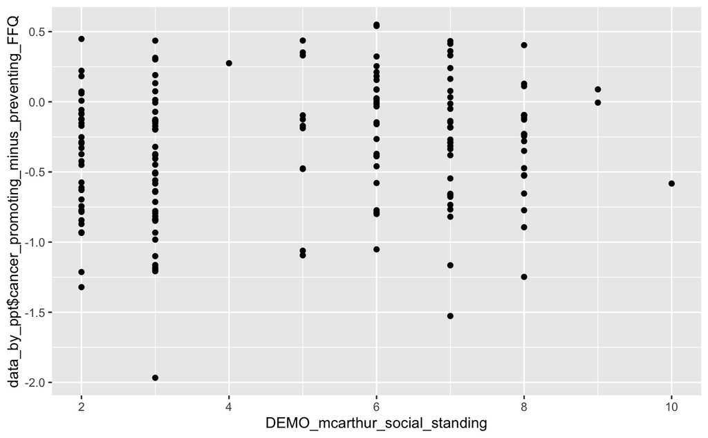

```r
ggplot(data_by_ppt,aes(DEMO_mcarthur_social_standing,data_by_ppt$cancer_promoting_minus_preventing_FFQ))+geom_point()
```

## Correlations

```r
correlational_items <- c(IVs,DVs)

corrplot::corrplot(cor(data_by_ppt[,correlational_items],use = "pairwise.complete.obs"),
method="number",type="upper",diag=FALSE,tl.srt=35,tl.cex=0.8,cl.cex=0.8,number.cex=0.8,order="hclust")
```

[figure not shown]

```r
NA
NA
```

```r
cor.test(data_by_ppt$SST_SSRT,data_by_ppt$bf_1)
```

```
    Pearson's product-moment correlation

data:  data_by_ppt$SST_SSRT and data_by_ppt$bf_1
t = 2.4609, df = 156, p-value = 0.01495
alternative hypothesis: true correlation is not equal to 0
95 percent confidence interval:
 0.03833114 0.33921583
sample estimates:
      cor
0.1933145
```

```r
cor.test(data_by_ppt$SST_SSRT,data_by_ppt$ROC_Crave_Minus_Neutral)
```

```
    Pearson's product-moment correlation

data:  data_by_ppt$SST_SSRT and data_by_ppt$ROC_Crave_Minus_Neutral
t = -2.2245, df = 127, p-value = 0.02788
alternative hypothesis: true correlation is not equal to 0
95 percent confidence interval:
 -0.35463568 -0.02151816
sample estimates:
       cor
-0.1936522
```

```r
cor.test(data_by_ppt$SST_SSRT,data_by_ppt$cancer_promoting_minus_preventing_FFQ)
```

```
    Pearson's product-moment correlation

data:  data_by_ppt$SST_SSRT and data_by_ppt$cancer_promoting_minus_preventing_FFQ
t = -1.3921, df = 190, p-value = 0.1655
alternative hypothesis: true correlation is not equal to 0
95 percent confidence interval:
 -0.23869636  0.04171732
sample estimates:
       cor
-0.1004846
```

```r
cor.test(data_by_ppt$SST_SSRT,data_by_ppt$FFQ_v2_Mean_Weighted_Nutrient_Density)
```

```
    Pearson's product-moment correlation

data:  data_by_ppt$SST_SSRT and data_by_ppt$FFQ_v2_Mean_Weighted_Nutrient_Density
t = 1.8321, df = 155, p-value = 0.06886
alternative hypothesis: true correlation is not equal to 0
95 percent confidence interval:
 -0.01130571  0.29548975
sample estimates:
      cor
0.1455903
```

```r
cor.test(data_by_ppt$SST_SSRT,data_by_ppt$FFQ_v2_Mean_Dietary_Nutrient_Density)
```

```
    Pearson's product-moment correlation

data:  data_by_ppt$SST_SSRT and data_by_ppt$FFQ_v2_Mean_Dietary_Nutrient_Density
t = 1.5535, df = 155, p-value = 0.1223
alternative hypothesis: true correlation is not equal to 0
95 percent confidence interval:
 -0.03346527  0.27512398
sample estimates:
      cor
0.1238219
```